# Citi Bike: Usage patterns + insurer decision assets

This notebook is built to work with the repo Make targets (e.g.make report-both YEARS="YYYY YYYY..." MONTHS="1 2 .. 12") It **always prefers the current run** (your `summaries/<RUN_TAG>/` folder) when you pass `YEARS/MONTHS`, so the report reflects exactly what you ingested.

## How to run (recommended)

From the repo root:

```
make all-both YEARS="YYYY YYYY..." MONTHS="1 2 .. 12"

The Makefile sets environment variables (e.g. `CITIBIKE_PARQUET_DIR`, `CITIBIKE_YEARS`, `CITIBIKE_MONTHS`) which this notebook reads.
```

```python
# --- Setup (STRICT + explicit risk variants): repo paths, run dirs, safe CSV loads ---

from __future__ import annotations

from pathlib import Path
import os
import re
import pandas as pd
import matplotlib.pyplot as plt

# Optional display in notebooks
try:
    from IPython.display import display, Markdown
except Exception:
    display = print
    Markdown = lambda x: x

# nbconvert-friendly
try:
    get_ipython().run_line_magic("matplotlib", "inline")
except Exception:
    pass
plt.ioff()

def find_repo_root(start: Path) -> Path:
    start = start.resolve()
    for p in [start, *start.parents]:
        if (p / "Makefile").exists():
            return p
    raise FileNotFoundError(
        "Could not find repo root (Makefile) by walking up from:\n"
        f"  CWD={Path.cwd().resolve()}"
    )

def _parse_int_list(val: str | None):
    if val is None:
        return None
    s = str(val).strip()
    if not s:
        return None
    parts = re.split(r"[,\s]+", s)
    out = []
    for p in parts:
        if not p:
            continue
        try:
            out.append(int(p))
        except Exception:
            pass
    return out or None

def read_csv_strict(path: Path) -> pd.DataFrame:
    if not path.exists():
        raise FileNotFoundError(f"Missing required CSV: {path}")
    return pd.read_csv(path)

def read_csv_optional(path: Path) -> pd.DataFrame | None:
    return pd.read_csv(path) if path.exists() else None

REPO_ROOT = find_repo_root(Path.cwd())
SUMMARIES_ROOT = REPO_ROOT / "summaries"

PARQUET_DIR_ENV = (os.environ.get("CITIBIKE_PARQUET_DIR") or "").strip()
RUN_DIR_ENV     = (os.environ.get("CITIBIKE_RUN_DIR") or "").strip()
MODE_ENV        = (os.environ.get("CITIBIKE_MODE") or os.environ.get("MODE") or "").strip().lower()

YEARS_FILTER  = _parse_int_list(os.environ.get("CITIBIKE_YEARS")  or os.environ.get("YEARS"))
MONTHS_FILTER = _parse_int_list(os.environ.get("CITIBIKE_MONTHS") or os.environ.get("MONTHS"))

PARQUET_DIR = Path(PARQUET_DIR_ENV) if PARQUET_DIR_ENV else Path()

if RUN_DIR_ENV:
    RUN_DIR = Path(RUN_DIR_ENV)
else:
    run_tag = PARQUET_DIR.name if str(PARQUET_DIR).strip() else ""
    RUN_DIR = (SUMMARIES_ROOT / run_tag) if run_tag else Path()

# Resolve relative paths against repo root
if str(RUN_DIR).strip() and (not RUN_DIR.is_absolute()):
    RUN_DIR = (REPO_ROOT / RUN_DIR).resolve()
if str(PARQUET_DIR).strip() and (not PARQUET_DIR.is_absolute()):
    PARQUET_DIR = (REPO_ROOT / PARQUET_DIR).resolve()

# Strict folder checks
if not SUMMARIES_ROOT.exists():
    raise FileNotFoundError(f"Expected summaries/ at: {SUMMARIES_ROOT} (run make summarize first)")

if not RUN_DIR.exists():
    raise FileNotFoundError(f"RUN_DIR not found: {RUN_DIR} (run make summarize first)")

if str(PARQUET_DIR).strip() and (not PARQUET_DIR.exists()):
    raise FileNotFoundError(f"PARQUET_DIR not found: {PARQUET_DIR} (run make ingest first)")

# Required run CSVs
REQUIRED_RUN_FILES = [
    "citibike_trips_by_year.csv",
    "citibike_trips_by_month.csv",
    "citibike_trips_by_dow.csv",
    "citibike_trips_by_hour.csv",
]
missing = [f for f in REQUIRED_RUN_FILES if not (RUN_DIR / f).exists()]
if missing:
    raise FileNotFoundError(
        f"Missing required summary CSVs in:\n  {RUN_DIR}\nMissing: {missing}\n"
        "Run: make summarize-only (or make summarize / make all)."
    )

print("REPO_ROOT:", REPO_ROOT)
print("RUN_DIR:", RUN_DIR)
print("PARQUET_DIR:", PARQUET_DIR if str(PARQUET_DIR).strip() else "(not set)")
print("MODE (env):", MODE_ENV or "(not set)")
print("YEARS_FILTER:", YEARS_FILTER, "MONTHS_FILTER:", MONTHS_FILTER)

# Figures folder
FIG_DIR = REPO_ROOT / "reports" / RUN_DIR.name / "figures"
FIG_DIR.mkdir(parents=True, exist_ok=True)
print("FIG_DIR:", FIG_DIR)

def savefig(filename: str):
    out = FIG_DIR / filename
    plt.savefig(out, dpi=200, bbox_inches="tight")
    print("Saved:", out)

# Load per-run summaries
df_year  = read_csv_strict(RUN_DIR / "citibike_trips_by_year.csv")
df_month = read_csv_strict(RUN_DIR / "citibike_trips_by_month.csv")
df_dow   = read_csv_strict(RUN_DIR / "citibike_trips_by_dow.csv")
df_hour  = read_csv_strict(RUN_DIR / "citibike_trips_by_hour.csv")

# Optional per-run outputs
df_station = read_csv_optional(RUN_DIR / "citibike_station_exposure.csv")

# Risk variants (overall + new per-year/per-month if present)
df_risk_overall = read_csv_optional(RUN_DIR / "station_risk_exposure_plus_crashproximity.csv")
df_risk_year    = read_csv_optional(RUN_DIR / "station_risk_exposure_plus_crashproximity_by_year.csv")
df_risk_ym      = read_csv_optional(RUN_DIR / "station_risk_exposure_plus_crashproximity_by_year_month.csv")

# Backward compat: keep df_risk pointing to "best available"
df_risk = df_risk_year if df_risk_year is not None else df_risk_overall

# Mode detection
mode = (
    str(df_year["mode"].iloc[0]).lower()
    if ("mode" in df_year.columns and len(df_year))
    else (MODE_ENV or "unknown")
)
print("Detected mode:", mode)

# Apply optional filters defensively
def _filter_year_month(df: pd.DataFrame) -> pd.DataFrame:
    out = df.copy()
    if YEARS_FILTER is not None and "year" in out.columns:
        out["year"] = pd.to_numeric(out["year"], errors="coerce")
        out = out[out["year"].isin(YEARS_FILTER)]
    if MONTHS_FILTER is not None and "month" in out.columns:
        out["month"] = pd.to_numeric(out["month"], errors="coerce")
        out = out[out["month"].isin(MONTHS_FILTER)]
    return out

df_year  = _filter_year_month(df_year)
df_month = _filter_year_month(df_month)
df_dow   = _filter_year_month(df_dow)
df_hour  = _filter_year_month(df_hour)

# Helpful run label
run_label = RUN_DIR.name

print("\nRisk inputs found:")
print(" - df_risk_overall:", "YES" if df_risk_overall is not None else "NO")
print(" - df_risk_year   :", "YES" if df_risk_year is not None else "NO")
print(" - df_risk_ym     :", "YES" if df_risk_ym is not None else "NO")
print("Using df_risk = ", "df_risk_year" if df_risk is df_risk_year else ("df_risk_overall" if df_risk is df_risk_overall else "None"))
```

```
REPO_ROOT: /home/hamzeh-khanpour/Desktop/CITIBIK-main
RUN_DIR: /home/hamzeh-khanpour/Desktop/CITIBIK-main/summaries/y2019_2020_2023_2025_m1_2_3_4_5_6_7_8_9_10_11_12_modenyc
PARQUET_DIR: /home/hamzeh-khanpour/Desktop/CITIBIK-main/data/processed/citibike_parquet/y2019_2020_2023_2025_m1_2_3_4_5_6_7_8_9_10_11_12_modenyc
MODE (env): nyc
YEARS_FILTER: [2019, 2020, 2023, 2025] MONTHS_FILTER: [1, 2, 3, 4, 5, 6, 7, 8, 9, 10, 11, 12]
FIG_DIR: /home/hamzeh-khanpour/Desktop/CITIBIK-main/reports/y2019_2020_2023_2025_m1_2_3_4_5_6_7_8_9_10_11_12_modenyc/figures
Detected mode: nyc

Risk inputs found:
 - df_risk_overall: YES
 - df_risk_year   : YES
 - df_risk_ym     : YES
Using df_risk =  df_risk_year
```

## Executive summary (optional)

If you generated `summary_highlights.md` for this run, we show it here.

```python
# --- Quick text highlights from summarize script (if present) ---
from pathlib import Path

# Prefer the variable if it exists, else derive from RUN_DIR (which setup should define)
hp = None
if "highlights_path" in globals():
    try:
        hp = highlights_path
    except Exception:
        hp = None

if hp is None:
    if "RUN_DIR" in globals():
        hp = Path(RUN_DIR) / "summary_highlights.md"
    else:
        # Last resort: try repo-relative "summaries/latest"
        hp = Path("summaries/latest/summary_highlights.md").resolve()

if hp.exists():
    txt = hp.read_text(encoding="utf-8", errors="ignore")
    try:
        display(Markdown(txt))
    except Exception:
        print(txt)
else:
    print("No summary_highlights.md found at:", hp)
```

Summary highlights

- Mode: **nyc**

Top 5 years by trips

- 2025: 45761685

- 2023: 35097909

- 2019: 20551697

- 2020: 19554112

Top 10 year-months by trips

- 2025-09: 5286096

- 2025-08: 5120938

- 2025-07: 4986852

- 2025-06: 4758167

- 2025-10: 4730876

- 2025-05: 4324746

- 2023-08: 3963117

- 2025-04: 3724288

- 2023-10: 3723784

- 2023-07: 3658311

Top 5 days-of-week by trips

- dow=2: 18334751

- dow=1: 18111886

- dow=3: 17945746

- dow=4: 17943023

- dow=5: 17115905

Top 5 hours by trips

- hour=17: 11325513

- hour=18: 10628927

- hour=16: 9126512

- hour=15: 8192381

- hour=19: 7946515

## 1) Yearly usage (comparison across years)

|  | mode | year | trips |
| --- | --- | --- | --- |
| 0 | nyc | 2019 | 20551697 |
| 1 | nyc | 2020 | 19554112 |
| 2 | nyc | 2023 | 35097909 |
| 3 | nyc | 2025 | 45761685 |

```
Saved: /home/hamzeh-khanpour/Desktop/CITIBIK-main/reports/y2019_2020_2023_2025_m1_2_3_4_5_6_7_8_9_10_11_12_modenyc/figures/01_trips_by_year.png
```

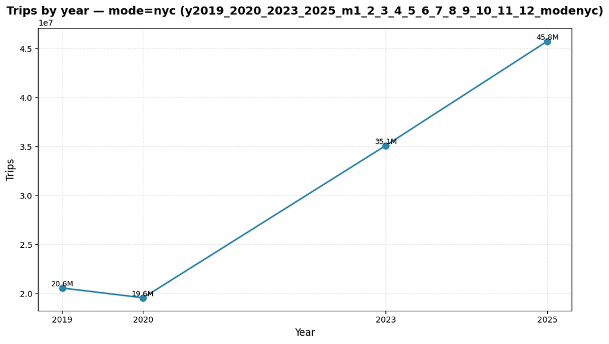

```python
# --- Trips by year (THIS RUN) ---
g = df_year.copy()

if "year" in g.columns:
    # Clean and prepare data
    g["year"] = pd.to_numeric(g["year"], errors="coerce")
    g = g.dropna(subset=["year"]).sort_values("year").reset_index(drop=True)

display(g)

# Plot
plt.figure(figsize=(10, 6))

if "year" in g.columns and "trips" in g.columns:
    # Extract values as plain lists (no pandas magic)
    years = [int(y) for y in g["year"]]
    trips = [int(t) for t in g["trips"]]

    # Plot with explicit year labels
    plt.plot(years, trips, marker="o", linewidth=2, markersize=8, color='#2E86AB')
    plt.xticks(years, [str(y) for y in years])  # Explicit year labels
    plt.grid(True, alpha=0.3, linestyle='--')

    # Add value labels on points
    for year, trip in zip(years, trips):
        plt.text(year, trip, f'{trip/1e6:.1f}M',
                ha='center', va='bottom', fontsize=9)

plt.title(f"Trips by year — mode={mode} ({run_label})", fontsize=14, fontweight='bold')
plt.xlabel("Year", fontsize=12)
plt.ylabel("Trips", fontsize=12)
plt.tight_layout()

savefig("01_trips_by_year.png")
plt.show()
```

## 2) Month patterns (comparison)

|  | mode | year | month | trips | days_in_month | trips_per_day |
| --- | --- | --- | --- | --- | --- | --- |
| 0 | nyc | 2019 | 1 | 967287 | 31 | 31202.806452 |
| 1 | nyc | 2019 | 2 | 943744 | 28 | 33705.142857 |
| 2 | nyc | 2019 | 3 | 1327960 | 31 | 42837.419355 |
| 3 | nyc | 2019 | 4 | 1766094 | 30 | 58869.800000 |
| 4 | nyc | 2019 | 5 | 1924563 | 31 | 62082.677419 |
| 5 | nyc | 2019 | 6 | 2125370 | 30 | 70845.666667 |
| 6 | nyc | 2019 | 7 | 2181064 | 31 | 70356.903226 |
| 7 | nyc | 2019 | 8 | 2344224 | 31 | 75620.129032 |
| 8 | nyc | 2019 | 9 | 2444900 | 30 | 81496.666667 |
| 9 | nyc | 2019 | 10 | 2092573 | 31 | 67502.354839 |
| 10 | nyc | 2019 | 11 | 1478708 | 30 | 49290.266667 |
| 11 | nyc | 2019 | 12 | 955210 | 31 | 30813.225806 |
| 12 | nyc | 2020 | 1 | 1243192 | 31 | 40102.967742 |
| 13 | nyc | 2020 | 2 | 1149391 | 29 | 39634.172414 |
| 14 | nyc | 2020 | 3 | 1071221 | 31 | 34555.516129 |
| 15 | nyc | 2020 | 4 | 684362 | 30 | 22812.066667 |
| 16 | nyc | 2020 | 5 | 1491340 | 31 | 48107.741935 |
| 17 | nyc | 2020 | 6 | 1887318 | 30 | 62910.600000 |
| 18 | nyc | 2020 | 7 | 2110845 | 31 | 68091.774194 |
| 19 | nyc | 2020 | 8 | 2334608 | 31 | 75309.935484 |
| 20 | nyc | 2020 | 9 | 2494393 | 30 | 83146.433333 |
| 21 | nyc | 2020 | 10 | 2254215 | 31 | 72716.612903 |
| 22 | nyc | 2020 | 11 | 1741341 | 30 | 58044.700000 |
| 23 | nyc | 2020 | 12 | 1091886 | 31 | 35222.129032 |
| 24 | nyc | 2023 | 1 | 1795015 | 31 | 57903.709677 |
| 25 | nyc | 2023 | 2 | 1695861 | 28 | 60566.464286 |
| 26 | nyc | 2023 | 3 | 2118683 | 31 | 68344.612903 |
| 27 | nyc | 2023 | 4 | 2749070 | 30 | 91635.666667 |
| 28 | nyc | 2023 | 5 | 3452818 | 31 | 111381.225806 |
| 29 | nyc | 2023 | 6 | 3450700 | 30 | 115023.333333 |
| 30 | nyc | 2023 | 7 | 3658311 | 31 | 118010.032258 |
| 31 | nyc | 2023 | 8 | 3963117 | 31 | 127842.483871 |
| 32 | nyc | 2023 | 9 | 3470121 | 30 | 115670.700000 |
| 33 | nyc | 2023 | 10 | 3723784 | 31 | 120122.064516 |
| 34 | nyc | 2023 | 11 | 2816189 | 30 | 93872.966667 |
| 35 | nyc | 2023 | 12 | 2204240 | 31 | 71104.516129 |
| 36 | nyc | 2025 | 1 | 2124109 | 31 | 68519.645161 |
| 37 | nyc | 2025 | 2 | 2030843 | 28 | 72530.107143 |
| 38 | nyc | 2025 | 3 | 3167652 | 31 | 102182.322581 |
| 39 | nyc | 2025 | 4 | 3724288 | 30 | 124142.933333 |
| 40 | nyc | 2025 | 5 | 4324746 | 31 | 139507.935484 |
| 41 | nyc | 2025 | 6 | 4758167 | 30 | 158605.566667 |
| 42 | nyc | 2025 | 7 | 4986852 | 31 | 160866.193548 |
| 43 | nyc | 2025 | 8 | 5120938 | 31 | 165191.548387 |
| 44 | nyc | 2025 | 9 | 5286096 | 30 | 176203.200000 |
| 45 | nyc | 2025 | 10 | 4730876 | 31 | 152608.903226 |
| 46 | nyc | 2025 | 11 | 3415726 | 30 | 113857.533333 |
| 47 | nyc | 2025 | 12 | 2091392 | 31 | 67464.258065 |

```
Saved: /home/hamzeh-khanpour/Desktop/CITIBIK-main/reports/y2019_2020_2023_2025_m1_2_3_4_5_6_7_8_9_10_11_12_modenyc/figures/02_trips_by_year_month.png
```

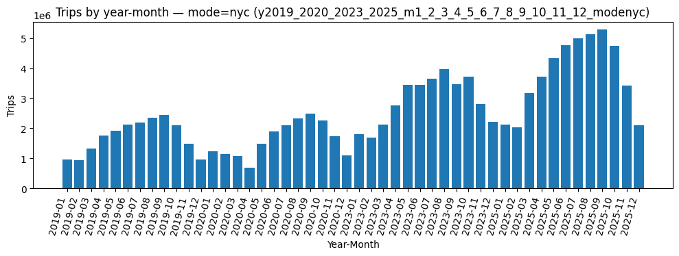

```python
# --- Trips by month (THIS RUN) ---
m = df_month.copy()

# Normalize month labels
if "month" in m.columns:
    m["month"] = pd.to_numeric(m["month"], errors="coerce").astype("Int64")
if "year" in m.columns:
    m["year"] = pd.to_numeric(m["year"], errors="coerce").astype("Int64")

display(m.sort_values([c for c in ["year", "month"] if c in m.columns]))

# If multiple years, show stacked-ish bars by year-month
if {"year", "month", "trips"}.issubset(m.columns):
    m2 = m.dropna(subset=["year","month"]).copy()
    m2["ym"] = m2["year"].astype(int).astype(str) + "-" + m2["month"].astype(int).astype(str).str.zfill(2)

    plt.figure(figsize=(10,4))
    plt.bar(m2["ym"], m2["trips"])
    plt.title(f"Trips by year-month — mode={mode} ({run_label})")
    plt.xlabel("Year-Month")
    plt.ylabel("Trips")
    plt.xticks(rotation=75, ha="right")
    plt.tight_layout()
    savefig("02_trips_by_year_month.png")
    plt.show()
else:
    print("Expected columns not present for trips-by-month plot. Have:", list(m.columns))
```

| year month | 2019 | 2020 | 2023 | 2025 |
| --- | --- | --- | --- | --- |
| 1 | 967287 | 1243192 | 1795015 | 2124109 |
| 2 | 943744 | 1149391 | 1695861 | 2030843 |
| 3 | 1327960 | 1071221 | 2118683 | 3167652 |
| 4 | 1766094 | 684362 | 2749070 | 3724288 |
| 5 | 1924563 | 1491340 | 3452818 | 4324746 |
| 6 | 2125370 | 1887318 | 3450700 | 4758167 |
| 7 | 2181064 | 2110845 | 3658311 | 4986852 |
| 8 | 2344224 | 2334608 | 3963117 | 5120938 |
| 9 | 2444900 | 2494393 | 3470121 | 5286096 |
| 10 | 2092573 | 2254215 | 3723784 | 4730876 |
| 11 | 1478708 | 1741341 | 2816189 | 3415726 |
| 12 | 955210 | 1091886 | 2204240 | 2091392 |

```
Saved: /home/hamzeh-khanpour/Desktop/CITIBIK-main/reports/y2019_2020_2023_2025_m1_2_3_4_5_6_7_8_9_10_11_12_modenyc/figures/03_month_by_year_lines.png
```

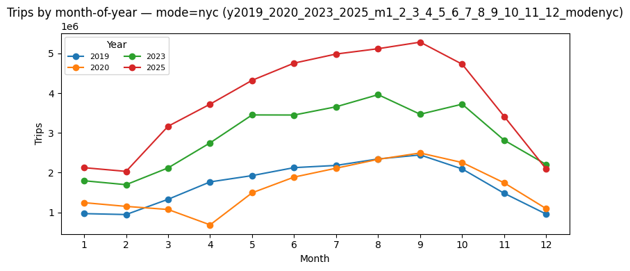

```python
# --- Month-of-year seasonality (line chart per year) ---
m = df_month.copy()
if not {"year","month","trips"}.issubset(m.columns):
    print("Month table missing required columns:", list(m.columns))
else:
    m["year"]  = pd.to_numeric(m["year"], errors="coerce").astype("Int64")
    m["month"] = pd.to_numeric(m["month"], errors="coerce").astype("Int64")
    m = m.dropna(subset=["year","month"]).copy()
    m = m.sort_values(["year","month"])

    pivot = m.pivot_table(index="month", columns="year", values="trips", aggfunc="sum").sort_index()
    display(pivot)

    plt.figure(figsize=(8,4))
    for y in pivot.columns:
        plt.plot(pivot.index.astype(int), pivot[y], marker="o", label=str(int(y)))
    plt.title(f"Trips by month-of-year — mode={mode} ({run_label})")
    plt.xlabel("Month")
    plt.ylabel("Trips")
    plt.xticks(range(1,13))
    plt.legend(title="Year", ncol=2, fontsize=8)
    plt.tight_layout()
    savefig("03_month_by_year_lines.png")
    plt.show()
```

## 3) Day-of-week patterns (comparison)

```
Years present in df_dow: [2019, 2020, 2023, 2025]

Trips by day-of-week (pivot):
```

| dow | year dow_name | 2019 | 2020 | 2023 | 2025 |
| --- | --- | --- | --- | --- | --- |
| 0 | Monday | 2922106 | 2553803 | 4730831 | 6110677 |
| 1 | Tuesday | 3157951 | 2805470 | 5283220 | 6865245 |
| 2 | Wednesday | 3146705 | 2834665 | 5537911 | 6815470 |
| 3 | Thursday | 3001240 | 2703602 | 5437743 | 6803161 |
| 4 | Friday | 3117824 | 2686101 | 5139218 | 6999880 |
| 5 | Saturday | 2815274 | 3097093 | 4652966 | 6550572 |
| 6 | Sunday | 2390597 | 2873378 | 4316020 | 5616680 |

```
Share of trips within each year (%):
```

| dow | year dow_name | 2019 | 2020 | 2023 | 2025 |
| --- | --- | --- | --- | --- | --- |
| 0 | Monday | 14.22 | 13.06 | 13.48 | 13.35 |
| 1 | Tuesday | 15.37 | 14.35 | 15.05 | 15.00 |
| 2 | Wednesday | 15.31 | 14.50 | 15.78 | 14.89 |
| 3 | Thursday | 14.60 | 13.83 | 15.49 | 14.87 |
| 4 | Friday | 15.17 | 13.74 | 14.64 | 15.30 |
| 5 | Saturday | 13.70 | 15.84 | 13.26 | 14.31 |
| 6 | Sunday | 11.63 | 14.69 | 12.30 | 12.27 |

```
Saved: /home/hamzeh-khanpour/Desktop/CITIBIK-main/reports/y2019_2020_2023_2025_m1_2_3_4_5_6_7_8_9_10_11_12_modenyc/figures/10_dow_year_comparison_abs.png
```

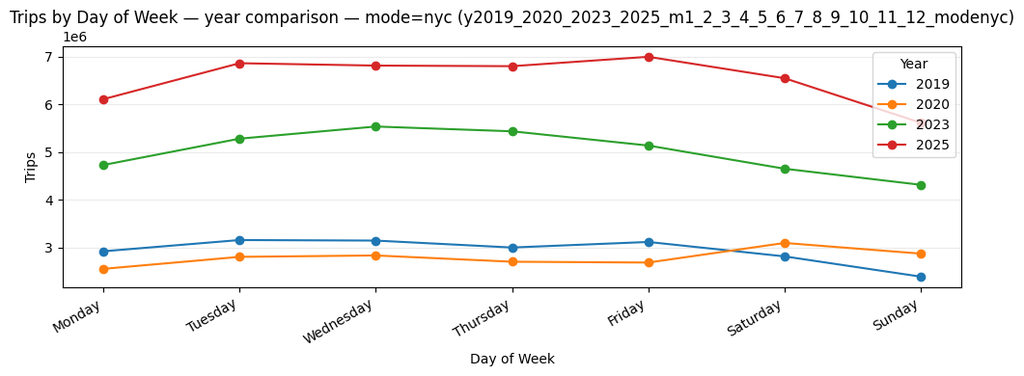

```
Saved: /home/hamzeh-khanpour/Desktop/CITIBIK-main/reports/y2019_2020_2023_2025_m1_2_3_4_5_6_7_8_9_10_11_12_modenyc/figures/10_dow_year_comparison_pct.png
```

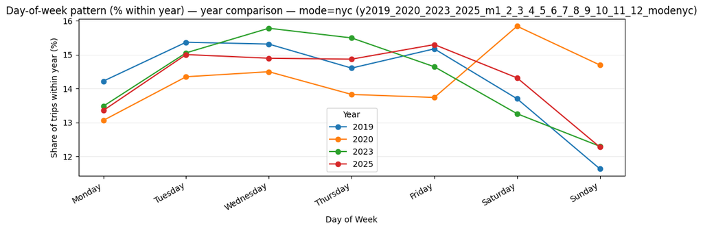

```
Saved: /home/hamzeh-khanpour/Desktop/CITIBIK-main/reports/y2019_2020_2023_2025_m1_2_3_4_5_6_7_8_9_10_11_12_modenyc/figures/10_weekday_weekend_year_comparison_pct.png
```

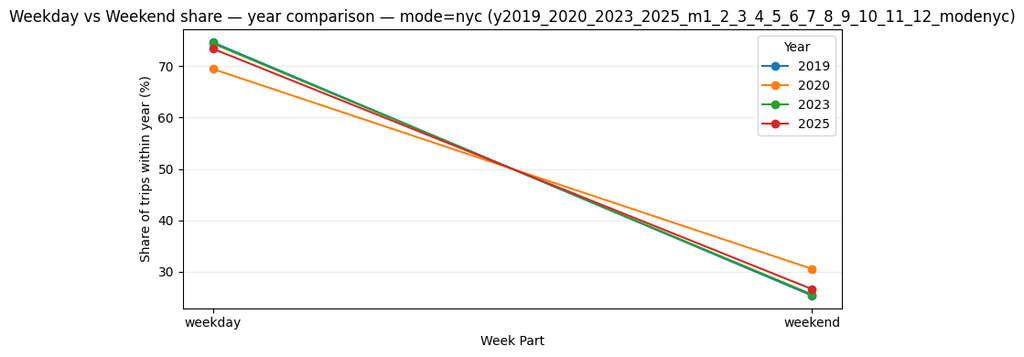

```python
# --- Day-of-week patterns (comparison across years; robust even if dow_name missing) ---

import numpy as np
import pandas as pd
import matplotlib.pyplot as plt

if df_dow is None or len(df_dow) == 0:
    print("df_dow is None/empty; skipping DOW comparison.")
else:
    d = df_dow.copy()

    # ---- Required columns ----
    req = {"dow", "trips"}
    missing = [c for c in req if c not in d.columns]
    if missing:
        raise KeyError(f"df_dow missing required columns {missing}. Have: {list(d.columns)}")

    # Ensure year exists for "comparison"
    if "year" not in d.columns:
        print("df_dow has no 'year' column; cannot do year comparison.")
        display(d.head(20))
    else:
        # ---- Clean types ----
        d["dow"] = pd.to_numeric(d["dow"], errors="coerce")
        d["trips"] = pd.to_numeric(d["trips"], errors="coerce").fillna(0)
        d["year"] = pd.to_numeric(d["year"], errors="coerce")
        d = d.dropna(subset=["dow", "year"]).copy()
        d["dow"] = d["dow"].astype(int)
        d["year"] = d["year"].astype(int)

        # ---- Add dow_name if missing (deterministic mapping) ----
        if "dow_name" not in d.columns:
            dow_map = {
                0: "Monday", 1: "Tuesday", 2: "Wednesday", 3: "Thursday",
                4: "Friday", 5: "Saturday", 6: "Sunday",
            }
            d["dow_name"] = d["dow"].map(dow_map).fillna(d["dow"].astype(str))

        # ---- Add week_part if missing ----
        if "week_part" not in d.columns:
            d["week_part"] = np.where(d["dow"] >= 5, "weekend", "weekday")

        years = sorted(d["year"].unique().tolist())
        print("Years present in df_dow:", years)

        # ---- TABLE 1: pivot (dow_name x year) ----
        pivot = (
            d.pivot_table(index=["dow", "dow_name"], columns="year", values="trips", aggfunc="sum")
             .sort_index(level=0)
        )
        print("\nTrips by day-of-week (pivot):")
        display(pivot)

        # ---- TABLE 2: shares within each year (percent of yearly total) ----
        shares = (
            d.groupby(["year", "dow", "dow_name"], as_index=False)["trips"]
             .sum()
             .sort_values(["year", "dow"])
        )
        shares["pct_of_year"] = shares["trips"] / shares.groupby("year")["trips"].transform("sum") * 100.0
        share_pivot = (
            shares.pivot_table(index=["dow", "dow_name"], columns="year", values="pct_of_year", aggfunc="first")
                  .sort_index(level=0)
        )
        print("\nShare of trips within each year (%):")
        display(share_pivot.round(2))

        # ---- PLOT 1: absolute trips per DOW for each year ----
        plt.figure(figsize=(10, 4))
        x_labels = [f"{n}" for n in pivot.index.get_level_values("dow_name")]
        x = np.arange(len(x_labels))

        for yy in years:
            if yy in pivot.columns:
                plt.plot(x, pivot[yy].values, marker="o", label=str(yy))

        plt.xticks(x, x_labels, rotation=30, ha="right")
        plt.xlabel("Day of Week")
        plt.ylabel("Trips")
        plt.title(f"Trips by Day of Week — year comparison — mode={mode} ({run_label})")
        plt.grid(alpha=0.25, axis="y")
        plt.legend(title="Year")
        plt.tight_layout()
        savefig("10_dow_year_comparison_abs.png")
        plt.show()

        # ---- PLOT 2: % share per DOW for each year (better for pattern comparison) ----
        plt.figure(figsize=(10, 4))
        for yy in years:
            if yy in share_pivot.columns:
                plt.plot(x, share_pivot[yy].values, marker="o", label=str(yy))

        plt.xticks(x, x_labels, rotation=30, ha="right")
        plt.xlabel("Day of Week")
        plt.ylabel("Share of trips within year (%)")
        plt.title(f"Day-of-week pattern (% within year) — year comparison — mode={mode} ({run_label})")
        plt.grid(alpha=0.25, axis="y")
        plt.legend(title="Year")
        plt.tight_layout()
        savefig("10_dow_year_comparison_pct.png")
        plt.show()

        # ---- OPTIONAL: weekday vs weekend bar per year ----
        wp = (
            d.groupby(["year", "week_part"], as_index=False)["trips"]
             .sum()
             .sort_values(["year", "week_part"])
        )
        wp["pct"] = wp["trips"] / wp.groupby("year")["trips"].transform("sum") * 100.0

        plt.figure(figsize=(8, 4))
        # make consistent order
        order = ["weekday", "weekend"]
        for yy in years:
            sub = wp[wp["year"] == yy].copy()
            sub["week_part"] = pd.Categorical(sub["week_part"], categories=order, ordered=True)
            sub = sub.sort_values("week_part")
            plt.plot(sub["week_part"].astype(str), sub["pct"].values, marker="o", label=str(yy))

        plt.xlabel("Week Part")
        plt.ylabel("Share of trips within year (%)")
        plt.title(f"Weekday vs Weekend share — year comparison — mode={mode} ({run_label})")
        plt.grid(alpha=0.25, axis="y")
        plt.legend(title="Year")
        plt.tight_layout()
        savefig("10_weekday_weekend_year_comparison_pct.png")
        plt.show()
```